# PG1_INFORME

## Percepción del vegetarianismo

**Cantidad de palabras: 3981**

## **Índice:**

1. Introducción
- Relevancia y contexto
- Marco teórico
- Objetivos
2. Datos
- Proceso de recolección de datos
- Población, muestra y muestreo
3. Variables
4. Limpieza de datos
5. Análisis descriptivo
- Descriptores univariables y gráficos
- Descriptores bivariables y gráficos

## **1. Introducción**

### Relevancia y contexto

En la actualidad, el vegetarianismo ha adquirido una mayor relevancia debido a los crecientes debates sobre la sostenibilidad, la salud y el bienestar animal. Cada vez más personas optan por adoptar una dieta vegetariana o vegana como parte de su estilo de vida. En este contexto, resulta crucial evaluar la disponibilidad y la calidad de las opciones alimentarias vegetarianas en diferentes entornos, incluyendo instituciones educativas. Estas desempeñan un papel fundamental en la promoción de estilos de vida saludables entre los estudiantes. La inclusión de opciones alimentarias vegetarianas, no solo contribuye a satisfacer las necesidades de una población estudiantil cada vez más diversa, sino que también fomenta la adopción de hábitos alimentarios más saludables y sostenibles.

En este estudio, nos enfocaremos en evaluar la percepción acerca del vegetarianismo y de la oferta alimentaria entre los estudiantes del cuarto y quinto ciclo de la Universidad de Ingeniería y Tecnología (UTEC) durante el semestre 2023-I.

Esto permitirá identificar posibles áreas de mejora y diseñar estrategias que promuevan una alimentación más saludable y acorde con las preferencias de los estudiantes. Asimismo, comprender la proporción de estudiantes veganos y vegetarianos en la universidad; analizar sus actitudes y disposición hacia el vegetarianismo es fundamental para adaptar los servicios de alimentación y satisfacer sus necesidades.

### Marco teórico:

**Vegetarianismo y veganismo:**

El vegetarianismo se refiere a una dieta basada principalmente en alimentos de origen vegetal, excluyendo la carne animal. Por otro lado, el veganismo implica una elección de estilo de vida más amplia que excluye todos los productos de origen animal, no solo en la alimentación, sino también en otros aspectos como la vestimenta y los productos de cuidado personal. Ambas opciones tienen diversas motivaciones, que pueden incluir preocupaciones por el bienestar animal, la salud personal y la sostenibilidad ambiental.

**Especismo**

El especismo es un concepto que se refiere a la discriminación o consideración desigual de los seres vivos basada en su especie. En nuestra sociedad, muchos consideran que los animales no humanos tienen un estatus inferior y son tratados como recursos o productos para satisfacer nuestras necesidades y deseos. Cuando reflexionamos sobre el especismo en relación con el vegetarianismo, podemos cuestionar por qué consideramos aceptable el consumo de carne de ciertos animales, como vacas, cerdos y pollos, pero no el de otros, como perros o gatos. Esta consideración selectiva basada en la especie refleja una discriminación injusta y subraya la existencia de un trato desigual hacia los animales. Al tomar conciencia del especismo, podemos reflexionar sobre nuestras elecciones alimentarias y considerar alternativas más éticas y compasivas.

**Sostenibilidad y vegetarianismo**

La sostenibilidad es un concepto ampliamente discutido en el ámbito ambiental y se refiere a la capacidad de satisfacer las necesidades presentes sin comprometer la capacidad de las generaciones futuras para satisfacer sus propias necesidades. En el contexto de la alimentación, adoptar una dieta vegetariana ha sido reconocido como una estrategia efectiva para promover la sostenibilidad y reducir el impacto ambiental. La producción de alimentos de origen animal, especialmente la carne, requiere grandes cantidades de recursos naturales, como agua, tierra y energía. Además, contribuye significativamente a la deforestación, la emisión de gases de efecto invernadero y la contaminación del agua y el suelo.

La ONU señala en un informe que una alimentación vegana salvaría al mundo del hambre. “Un cambio global hacia una dieta vegana es vital para salvar al mundo del hambre, la escasez de combustible y los peores impactos del cambio climático”.

**Salud y vegetarianismo**

El vegetarianismo no solo tiene implicaciones positivas en términos de sostenibilidad y ética, sino que también se ha asociado con numerosos beneficios para la salud.

La Organización Mundial de la Salud (OMS) recomienda en su publicación Las dietas basadas en plantas y su impacto en la salud, la sostenibilidad y el medio ambiente (2021), una dieta donde predominen los alimentos de origen vegetal y bajos en sal, grasas saturadas y azúcares añadidos

### Objetivos:

**Objetivo principal:** Evaluar la percepción del vegetarianismo y la oferta alimentaria vegetariana en los estudiantes de 4to y 5to ciclo de UTEC en el semestre 2023-I.

**Objetivos específicos:** 1.Conocer la cantidad de estudiantes veganos o vegetarianos del 4to ciclo en UTEC. 2.Evaluar el nivel de conocimiento sobre la cosmovisión o visión integral del vegetarianismo entre la población estudiantil de la universidad UTEC. 3. Analizar las actitudes de los estudiantes hacia el vegetarianismo y su disposición a adoptar esta dieta en el futuro. 4. Evaluar la percepción de los estudiantes de 4to ciclo de UTEC hacia la oferta alimentaria vegetariana de UTEC.

## **2. Datos:**

### **Proceso de recolección de datos:**

Para realizar la recolección de datos, realizamos una encuesta, la cual contiene 24 variables que nos servirán para nuestro estudio estadístico y está dirigida a los estudiantes de 4to y 5to ciclo de UTEC. Elegimos elaborar nuestra encuesta ya que buscamos una base de datos que se adecúe a los objetivos de nuestra investigación. Las condiciones bajo las cuales se llevó a cabo esta encuesta fueron, en cierto sentido, convenientes, de manera rápida y fácil para los estudiantes, ya que todos los estudiantes tienen algún dispositivo tecnológico para realizarla y cuentan con el internet requerido. Así mismo, el método operativo del llenado de encuestas fue el siguiente: Llegamos a nuestra población a través de las redes sociales y de manera presencial, en particular usamos WhatsApp, conjuntamente con el link y el código que dirigía a la encuesta. Virtualmente enviamos nuestro link a los estudiantes y a diferentes grupos de estudio, esto último lo realizamos con cuidado de no generar spam, y de manera presencial recorrimos la universidad ofreciendo el llenado de la encuesta a los estudiantes que se encontraban aptos. Como una estrategia más usamos el incentivo, este coincidía en que por cada encuesta que era llenada por los estudiantes se les regalaba una galleta Oreo, la cual se relaciona mucho con nuestro proyecto pues es considerada como una galleta vegana.

### **Población, muestra y muestreo:**

**Población:** Estudiantes de 4to y 5to ciclo de UTEC que están cursando el semestre 2023-1.

**Muestra:** Los estudiantes de la universidad de 4to y 5to ciclo que tengan entre 16 y 30 años,nuestro tamaño de muestra es de 191.

**Muestreo:** Muestreo por conveniencia.

## **3. Variables:**

| Pregunta | Variable | Tipo de Variable | Restricciones |
| --- | --- | --- | --- |
| ¿Qué ciclo estás cursando este 2023-1? | Ciclo | Numérica discreta | Se evalúa a alumnos de 4to y 5to ciclo. |
| Edad (años) | Edad | Numérica discreta | Se seleccionarán edades en el rango de 16 a 30 años. |
| Peso (Kg) | Peso | Numérica continua | Se seleccionarán pesos en el rango de 40 a 100 kg. |
| Sexo | Sexo | Categórica nominal | Solo se selecciona entre “femenino”, “masculino” y “otro”. |
| Carrera | Carrera | Categórica nominal | Aplica para todas las carreras a excepción de la carrera ciencia de datos, ya que es imposible que haya personas en 4to o 5to ciclo, pues la carrera es reciente. |
| Si te encuentras en la universidad. ¿Cuánto tiempo en minutos te demoras en comprar un almuerzo dentro de UTEC? | TiempoUtec | Numérica discreta | El tiempo se encuentra expresado en minutos, en un rango de 5 a 60 minutos. Si colocasen 0 correspondería a que no compran su almuerzo en UTEC serán reemplazados por NA’s. |
| Si te encuentras en la universidad. ¿Cuánto tiempo en minutos te demoras en comprar un almuerzo fuera de UTEC? | TiempoFuera | Numérica discreta | El tiempo está expresado en minutos, en un rango de 10 a 120 minutos. Si colocasen 0 correspondería a que no compran su almuerzo fuera de UTEC y serán reemplazados por NA’s. |
| ¿Cuántas veces a la semana compras almuerzos en UTEC? | VecesUtec | Numérica discreta | Se toma en el intervalo de 0 a 7, donde los ceros correspoden a personas que no almuerzan en UTEC y serán reemplazados por NA’s para que posteriormente los cálculos sean correctos. |
| ¿Cuán satisfecho estas con los almuerzos que compras en UTEC? | Satisfaccion | Categórica numérica | Se encuentra limitado por niveles de satisfacción y una opción que indica que el estudiante nunca compra almuerzos en UTEC. |
| ¿ Cuánto es lo mínimo de dinero, en soles, que gastas en un almuerzo? | PrecioMinimo | Numérica continua | Se consideran precios de almuerzos en un rango de 5 a 30 soles, donde los ceros corresponden a personas que no gastan en almuerzo y serán reemplazados por NA’s. |
| ¿ Cuánto es lo máximo de dinero, en soles, que gastas en un almuerzo? | PrecioMaximo | Numérica continua | Se consideran precios de almuerzos en un rango de 10 a 50 soles, donde los ceros corresponden a personas que no gastan en almuerzo y serán reemplazados por NA’s. |
| ¿Cuál es tu nivel de conocimiento sobre el vegetarianismo? | Conocimiento | Numérica ordinal | Se selecciona entre en opciones que van desde un conocimiento “nada” hasta uno “avanzado”. |
| ¿Eres vegano o vegetariano? | Vegetarianismo | Categórica nominal | Se restringe en 3 opciones: “Sí” , “No” , “No, pero desearía serlo”. |
| ¿Cuál es el motivo para adoptar o por el que adoptaste el vegetarianismo a tu vida? | MotivoSí | Categórica nominal | Se restringe en las siguientes opciones: “Salud”, “Entorno familiar y/o social”, “Obligación” “Interés por los derechos de los animales”, “Creencias”, “Sostenibilidad y medio ambiente”, “No adoptaría … |
| ¿Cuál es la razón principal por la cual no adoptarías una dieta vegetariana? | MotivoNo | Categórica nominal | Se restringe en: “Salud”, “Gusto personal”, “Costo”, “Sí adoptaría una dieta vegetariana”, “Soy vegetariano o vegano”. |
| En caso seas vegano o vegetariano. ¿Hace cuánto tiempo lo eres? | TiempoVeg | Numérica discreta | Se aceptan valores expresados en “años” y en “meses”, para posteriormente convertirlos a meses. Así mismo, los ceros encontrados corresponden a personas que no son vegetarianos ni veganos, los cuales … |
| ¿Qué tan preocupado estás por la crueldad animal en la producción de alimentos? | CrueldadAnimal | Categórica ordinal | Será determinada por 5 opciones de los sigueientes niveles: “Nada”, “Poco”, “Regular”, “Bastante”, “Mucho”. |
| ¿Qué tan importante es para ti la sostenibilidad y el medio ambiente en la elección de alimentos? | MedioAmbiente | Categórica ordinal | Se determina por: “Muy importante”, “Importante”, “Muy poco importante”, “Nada importante”, “No tengo conocimiento sobre su implicancia”. |
| ¿Qué tanto conocimiento tienes acerca de las implicaciones ambientales y éticas de la producción de alimentos? | ConocAmbien | Categórica ordinal | Se selecciona entre un número del 1 al 5, donde 1 es muy bajo y 5 es muy alto. |
| ¿Qué tan interesado estarías en aprender más acerca de la dieta vegetariana? | AprenderVeg | Categórica ordinal | Se determina en: “Muy interesado”, “Interesado”, “Muy poco interesado”, “Nada interesado”. |
| ¿Qué tan interesado estarías en adoptar una dieta vegetariana en el futuro? | AdoptarVeg | Categórica ordinal | Se selecciona un número del 1 al 5, donde 1 es nada interesado y 5 es muy interesado. |
| ¿Qué tan fácil es para ti encontrar opciones vegetarianas en UTEC? | OpcionesVeg | Categórica ordinal | Se determina por: “Fácil”, “Regular”, “Difícil”, “No tengo conocimiento sobre alimentos vegetarianos”, “No me importa conseguir alimentos vegetarianos. |
| ¿Cuánto es lo mínimo de dinero, en soles, que estarías dispuesto a pagar por un almuerzo vegetarianoen UTEC? | VegMin | Numérica continua | Se consideran precios de almuerzos en un rango de 5 a 30 soles, donde los ceros corresponden a personas que no gastarían en un almuerzo vegetariano y serán reemplazados por NA’s |
| ¿Cuánto es lo máximo de dinero, en soles, que estarías dispuesto a pagar por un almuerzo vegetariano en UTEC? | VegMax | Numérica continua | Se consideran precios de almuerzos en un rango de 10 a 50 soles, donde los ceros corresponden a personas que no gastarían en un almuerzo vegetariano y serán reemplazados por NA’s. |

## **4. Limpieza de datos**

Antes de dar inicio a nuestra limpieza de datos, realizaremos la lectura de nuestra base de datos para ejecutar todo el trabajo.

Cargamos la librería.

```r
library(readr)
```

Leemos el DataFrame.

```r
DF <- read_csv("PercepcionVegetarianismo.csv")
```

```
## -------------------------------------------------------- Delimiter: "," chr
## (18): Marca temporal, Sexo, Carrera, Si te encuentras en la universidad.... dbl
## (7): ¿Qué ciclo estás cursando este 2023-1?, Edad (años), Peso (Kg), ¿C... lgl
## (2): Dirección de correo electrónico, ¿Qué tan fácil es para ti encontr...
##   tan fácil es para ti encontrar opciones vegetarianas en UTEC?...24`
##   tan fácil es para ti encontrar opciones vegetarianas en UTEC?...27`
```

Con la función names, podemos conocer el nombre de todas nuestras variables:

```r
names(DF)
```

```
##  [1] "Marca temporal"
##  [2] "Dirección de correo electrónico"
##  [3] "¿Qué ciclo estás cursando este 2023-1?"
##  [4] "Edad (años)"
##  [5] "Peso (Kg)"
##  [6] "Sexo"
##  [7] "Carrera"
##  [8] "Si te encuentras en la universidad. ¿Cuánto tiempo en minutos te demoras en comprar un almuerzo dentro de UTEC? \nDesde que tomas la decisión de almorzar hasta obtener tu almuerzo."
##  [9] "Si te encuentras en la universidad. ¿Cuánto tiempo en minutos te demoras en comprar un almuerzo fuera de UTEC? \nDesde que tomas la decisión de almorzar hasta obtener tu almuerzo."
## [10] "¿Cuántas veces a la semana compras almuerzos en UTEC?"
## [11] "¿Cuán satisfecho estas con los almuerzos que compras en UTEC? En caso no consumas coloca la última opción"
## [12] "¿ Cuánto es lo mínimo de dinero, en soles, que gastas en un almuerzo?\nEjemplo: 10.5"
## [13] "¿ Cuánto es lo máximo de dinero, en soles, que gastas en un almuerzo?\nEjemplo: 15.5"
## [14] "¿Cuál es tu nivel de conocimiento sobre el vegetarianismo? [Nivel]"
## [15] "¿Eres vegano o vegetariano?"
## [16] "¿Cuál es el motivo para adoptar o por el que adoptaste el vegetarianismo a tu vida? \nSi no adoptarías ninguno coloca la última opción"
## [17] "¿Cuál es la razón principal por la cual no adoptarías una dieta vegetariana? (salud, gusto personal, costo, entre otros)"
## [18] "En caso seas vegano o vegetariano. ¿Hace cuánto tiempo lo eres?"
## [19] "¿Qué tan preocupado estás por la crueldad animal en la producción de alimentos? [Nivel]"
## [20] "¿Qué tan importante es para ti la sostenibilidad y el medio ambiente en la elección de alimentos?"
## [21] "¿Qué tanto conocimiento tienes acerca de las implicaciones ambientales y éticas de la producción de alimentos? (del 1 al 5, donde 1 es muy bajo y 5 es muy alto)"
## [22] "¿Qué tan interesado estarías en aprender más acerca de la dieta vegetariana? \n"
## [23] "¿Qué tan interesado estarías en adoptar una dieta vegetariana en el futuro? (del 1 al 5, donde 1 es nada interesado y 5 es muy interesado)"
## [24] "¿Qué tan fácil es para ti encontrar opciones vegetarianas en UTEC?...24"
## [25] "¿Cuánto es lo mínimo de dinero, en soles, que estarías dispuesto a pagar por un almuerzo vegetariano en UTEC?"
## [26] "¿Cuánto es lo máximo de dinero, en soles, que estarías dispuesto a pagar por un almuerzo vegetariano en UTEC?"
## [27] "¿Qué tan fácil es para ti encontrar opciones vegetarianas en UTEC?...27"
```

Cambiamos el nombre a las variables:

Cargamos la librería dplyr:

```r
library(dplyr)
DF %>% rename (Ciclo=`¿Qué ciclo estás cursando este 2023-1?`,                Edad=`Edad (años)`, Peso= `Peso (Kg)`,                 TiempoUtec= `Si te encuentras en la universidad. ¿Cuánto tiempo en minutos te demoras en comprar un almuerzo dentro de UTEC? \nDesde que tomas la decisión de almorzar hasta obtener tu almuerzo.`,                 TiempoFuera=`Si te encuentras en la universidad. ¿Cuánto tiempo en minutos te demoras en comprar un almuerzo fuera de UTEC? \nDesde que tomas la decisión de almorzar hasta obtener tu almuerzo.`,                 VecesUtec= `¿Cuántas veces a la semana compras almuerzos en UTEC?`,                Satisfaccion=`¿Cuán satisfecho estas con los almuerzos que compras en UTEC? En caso no consumas coloca la última opción`,                 PrecioMinimo=`¿ Cuánto es lo mínimo de dinero, en soles, que gastas en un almuerzo?\nEjemplo: 10.5`,                 PrecioMaximo=`¿ Cuánto es lo máximo de dinero, en soles, que gastas en un almuerzo?\nEjemplo: 15.5`,                 Conocimiento=`¿Cuál es tu nivel de conocimiento sobre el vegetarianismo? [Nivel]`,                 Vegetarianismo=`¿Eres vegano o vegetariano?`,                 MotivoSí=`¿Cuál es el motivo para adoptar o por el que adoptaste el vegetarianismo a tu vida? \nSi no adoptarías ninguno coloca la última opción`,                MotivoNo=`¿Cuál es la razón principal por la cual no adoptarías una dieta vegetariana? (salud, gusto personal, costo, entre otros)`,                 TiempoVeg=`En caso seas vegano o vegetariano. ¿Hace cuánto tiempo lo eres?`,                 CrueldadAnimal=`¿Qué tan preocupado estás por la crueldad animal en la producción de alimentos? [Nivel]`,                 MedioAmbiente=`¿Qué tan importante es para ti la sostenibilidad y el medio ambiente en la elección de alimentos?`,                ConocAmbien= `¿Qué tanto conocimiento tienes acerca de las implicaciones ambientales y éticas de la producción de alimentos? (del 1 al 5, donde 1 es muy bajo y 5 es muy alto)`,                 AprenderVeg= `¿Qué tan interesado estarías en aprender más acerca de la dieta vegetariana? \n`,                 AdoptarVeg= `¿Qué tan interesado estarías en adoptar una dieta vegetariana en el futuro? (del 1 al 5, donde 1 es nada interesado y 5 es muy interesado)`,                 OpcionesVeg= `¿Qué tan fácil es para ti encontrar opciones vegetarianas en UTEC?...24`,                 VegMin= `¿Cuánto es lo mínimo de dinero, en soles, que estarías dispuesto a pagar por un almuerzo vegetariano en UTEC?`,                 VegMax=`¿Cuánto es lo máximo de dinero, en soles, que estarías dispuesto a pagar por un almuerzo vegetariano en UTEC?`)-> DFN
```

Corroboramos que los nombres sean los correctos:

A excepción de las variables que no van a ser utilizadas en el proceso y serán especificadas posteriormente.

```r
names(DFN)
```

```
##  [1] "Marca temporal"
##  [2] "Dirección de correo electrónico"
##  [3] "Ciclo"
##  [4] "Edad"
##  [5] "Peso"
##  [6] "Sexo"
##  [7] "Carrera"
##  [8] "TiempoUtec"
##  [9] "TiempoFuera"
## [10] "VecesUtec"
## [11] "Satisfaccion"
## [12] "PrecioMinimo"
## [13] "PrecioMaximo"
## [14] "Conocimiento"
## [15] "Vegetarianismo"
## [16] "MotivoSí"
## [17] "MotivoNo"
## [18] "TiempoVeg"
## [19] "CrueldadAnimal"
## [20] "MedioAmbiente"
## [21] "ConocAmbien"
## [22] "AprenderVeg"
## [23] "AdoptarVeg"
## [24] "OpcionesVeg"
## [25] "VegMin"
## [26] "VegMax"
## [27] "¿Qué tan fácil es para ti encontrar opciones vegetarianas en UTEC?...27"
```

Vemos si nuestras observaciones están completas:

```r
sum(complete.cases(DFN))
```

```
## [1] 0
```

```r
DFN<- select(DFN, -"Marca temporal")
```

```r
DFN<- select(DFN, -"Dirección de correo electrónico")
```

```r
DFN<- select(DFN, -"¿Qué tan fácil es para ti encontrar opciones vegetarianas en UTEC?...27")
```

Corroboramos nuestras variables:

```r
names(DFN)
```

```
##  [1] "Ciclo"          "Edad"           "Peso"           "Sexo"
##  [5] "Carrera"        "TiempoUtec"     "TiempoFuera"    "VecesUtec"
##  [9] "Satisfaccion"   "PrecioMinimo"   "PrecioMaximo"   "Conocimiento"
## [13] "Vegetarianismo" "MotivoSí"       "MotivoNo"       "TiempoVeg"
## [17] "CrueldadAnimal" "MedioAmbiente"  "ConocAmbien"    "AprenderVeg"
## [21] "AdoptarVeg"     "OpcionesVeg"    "VegMin"         "VegMax"
```

Haremos la limpieza de las variables, para lo cual iniciaremos ejecutando un resumen de cada una:

**VARIABLE CICLO:**

La variable Ciclo se encuentra limpia.

**VARIABLE EDAD:**

```r
summary(DFN$Edad)
```

```
##    Min. 1st Qu.  Median    Mean 3rd Qu.    Max.
##   16.00   19.00   20.00   20.24   20.00  118.00
```

Es imposible que una persona tenga 118 años.

Teniendo en cuenta nuestro rango determinado “envenenamos” con NA’s a las edades mayores de 30 años:

```r
DFN$Edad[DFN$Edad>30] <- NA
```

```r
summary(DFN$Edad)
```

```
##    Min. 1st Qu.  Median    Mean 3rd Qu.    Max.    NA's
##   16.00   19.00   20.00   19.73   20.00   29.00       1
```

**VARIABLE PESO:**

La variable peso se encuentra limpia

```r
summary(DFN$Peso)
```

```
##    Min. 1st Qu.  Median    Mean 3rd Qu.    Max.
##    45.0    57.0    63.0    63.9    70.0    94.0
```

**VARIABLE CARRERA:**

No se realizará ninguna limpieza.

**VARIABLE TIEMPO DENTRO DE UTEC:**

```r
unique(DFN$TiempoUtec)
```

```
##  [1] "20"                        "0"
##  [3] "10"                        "5"
##  [5] "15"                        "6"
##  [7] "8"                         "7"
##  [9] "30"                        "No como en la universidad"
## [11] "18"                        "45"
## [13] "27"                        "14"
## [15] "12"                        "25"
## [17] "40"                        "13"
## [19] "28"
```

```r
DFN$TiempoUtec[DFN$TiempoUtec=="No como en la universidad"]<- NA
DFN$TiempoUtec[DFN$TiempoUtec=="0"]<- NA
unique(DFN$TiempoUtec)
```

```
##  [1] "20" NA   "10" "5"  "15" "6"  "8"  "7"  "30" "18" "45" "27" "14" "12" "25"
## [16] "40" "13" "28"
```

```r
DFN$TiempoUtec<- strtoi(DFN$TiempoUtec)
summary(DFN$TiempoUtec)
```

```
##    Min. 1st Qu.  Median    Mean 3rd Qu.    Max.    NA's
##    5.00    7.00   10.00   13.82   20.00   45.00      70
```

**VARIABLE TIEMPO FUERA DE UTEC:**

```r
unique(DFN$TiempoFuera)
```

```
##  [1] "40"     "20"     "25"     "30"     "15"     "0"      "10"     "13"
##  [9] "60"     "24"     "22"     "14"     "45"     "12"     "30 min" "23"
## [17] "16"     "27"     "75"     "35"     "57"     "1 hora"
```

```r
DFN$TiempoFuera[DFN$TiempoFuera=="1 hora"]<- 60
DFN$TiempoFuera[DFN$TiempoFuera=="30 min"]<- 30
DFN$TiempoFuera[DFN$TiempoFuera==0]<- NA
```

```r
DFN$TiempoFuera <- strtoi(DFN$TiempoFuera)
summary(DFN$TiempoFuera)
```

```
##    Min. 1st Qu.  Median    Mean 3rd Qu.    Max.    NA's
##   10.00   15.00   20.00   24.08   30.00   75.00      26
```

**VARIABLE VECES QUE ALMUERZAN EN UTEC:**

```r
unique(DFN$VecesUtec)
```

```
## [1] 2 0 1 4 7 3 5 6
```

```r
DFN$VecesUtec[DFN$VecesUtec==0]<-NA
```

Finalmente tenemos un resumen claro de la variable.

```r
DFN$VecesUtec<- strtoi(DFN$VecesUtec)
summary(DFN$VecesUtec)
```

```
##    Min. 1st Qu.  Median    Mean 3rd Qu.    Max.    NA's
##   1.000   1.250   2.000   2.814   4.000   7.000      73
```

**VARIABLE SATISFACCIÓN DE LOS ALMUERZOS**

La variable está limpia.

**VARIABLE DEL PRECIO MÍNIMO EN ALMUERZO**

```r
summary(DFN$PrecioMinimo)
```

```
##    Length     Class      Mode
##       191 character character
```

```r
unique(DFN$PrecioMinimo)
```

```
##  [1] "9"        "10"       "11"       "12.5"     "12"       "15"
##  [7] "20"       "10.5"     "13"       "14"       "8"        "13.5"
## [13] "16"       "18"       "6"        "22"       "No gasto" "0"
```

```r
DFN$PrecioMinimo[DFN$PrecioMinimo=="No gasto"]<- NA
DFN$PrecioMinimo[DFN$PrecioMinimo==0]<- NA
```

```r
DFN$PrecioMinimo<- strtoi(DFN$PrecioMinimo)
summary(DFN$PrecioMinimo)
```

```
##    Min. 1st Qu.  Median    Mean 3rd Qu.    Max.    NA's
##    6.00   10.00   11.00   11.34   12.00   22.00       6
```

**VARIABLE DEL PRECIO MÁXIMO EN ALMUERZO**

```r
summary(DFN$PrecioMaximo)
```

```
##    Length     Class      Mode
##       191 character character
```

```r
unique(DFN$PrecioMaximo)
```

```
##  [1] "13"       "22.5"     "12"       "17"       "15"       "15.5"
##  [7] "20"       "11"       "25"       "28.5"     "16.5"     "30"
## [13] "18"       "21"       "12.5"     "16"       "27"       "10"
## [19] "28"       "14"       "35"       "24"       "40"       "13.9"
## [25] "19.50"    "14.8"     "No gasto" "0"
```

```r
DFN$PrecioMaximo[DFN$PrecioMaximo=="No gasto"]<- NA
DFN$PrecioMaximo[DFN$PrecioMaximo==0]<- NA
```

```r
DFN$PrecioMaximo <- strtoi(DFN$PrecioMaximo)
summary(DFN$PrecioMaximo)
```

```
##    Min. 1st Qu.  Median    Mean 3rd Qu.    Max.    NA's
##   10.00   14.00   15.00   17.14   20.00   40.00      15
```

**VARIABLE DEL TIEMPO SIENDO VEGETARIANO**

```r
summary(DFN$TiempoVeg)
```

```
##    Length     Class      Mode
##       191 character character
```

```r
unique(DFN$TiempoVeg)
```

```
## [1] "0"        "7 meses"  "2 años"   "2 meses"  "1 año"    "1 mes"    "23 meses"
```

```r
DFN$TiempoVeg[DFN$TiempoVeg=="1 año"]<- 12
DFN$TiempoVeg[DFN$TiempoVeg=="1 mes"]<- 1
DFN$TiempoVeg[DFN$TiempoVeg=="2 meses"]<- 2
DFN$TiempoVeg[DFN$TiempoVeg=="2 añoS"]<- 24
DFN$TiempoVeg[DFN$TiempoVeg=="7 meses"]<- 7
DFN$TiempoVeg[DFN$TiempoVeg=="23 meses"]<- 23
DFN$TiempoVeg[DFN$TiempoVeg==0]<- NA
```

```r
DFN$TiempoVeg<- strtoi(DFN$TiempoVeg)
summary(DFN$TiempoVeg)
```

```
##    Min. 1st Qu.  Median    Mean 3rd Qu.    Max.    NA's
##    1.00    1.75    7.00    7.50    8.25   23.00     183
```

**VARIABLE ALMUERZO VEGETARIANO PRECIO MÍNIMO:**

```r
summary(DFN$VegMin)
```

```
##    Length     Class      Mode
##       191 character character
```

```r
unique(DFN$VegMin)
```

```
##  [1] "13"   "10"   "12"   "15"   "0"    "20"   "11"   "12.5" "13.0" "14"
## [11] "O"    "15.5" "17"   "18"   "16"   "19"   "13.5"
```

```r
DFN$VegMin[DFN$VegMin==0]<- NA
DFN$VegMin[DFN$VegMin=="O"]<- NA
```

```r
DFN$VegMin<-strtoi(DFN$VegMin)
```

```r
summary(DFN$VegMin)
```

```
##    Min. 1st Qu.  Median    Mean 3rd Qu.    Max.    NA's
##   10.00   10.00   13.00   12.96   15.00   20.00      54
```

**VARIABLE ALMUERZO VEGETARIANO PRECIO MÁXIMO:**

```r
summary(DFN$VegMax)
```

```
##    Min. 1st Qu.  Median    Mean 3rd Qu.    Max.
##    0.00   10.00   15.00   12.99   19.00   30.00
```

```r
unique(DFN$VegMax)
```

```
##  [1] 15.0 20.0 18.0  0.0 25.0 16.0 20.5 12.0 13.0 17.0 14.0 19.0 10.0 11.0 24.0
## [16] 30.0 28.0 21.0 18.5 26.0
```

```r
DFN$VegMax[DFN$VegMax==0]<- NA
```

```r
summary(DFN$VegMax)
```

```
##    Min. 1st Qu.  Median    Mean 3rd Qu.    Max.    NA's
##   10.00   15.00   16.00   17.23   20.00   30.00      47
```

Resumen final de los NA’s de las variables

```r
library(funModeling)
df_status(DFN)
```

```
##          variable q_zeros p_zeros q_na  p_na q_inf p_inf      type unique
## 1           Ciclo       0       0    0  0.00     0     0   numeric      2
## 2            Edad       0       0    1  0.52     0     0   numeric     11
## 3            Peso       0       0    0  0.00     0     0   numeric     76
## 4            Sexo       0       0    0  0.00     0     0 character      3
## 5         Carrera       0       0    0  0.00     0     0 character     12
## 6      TiempoUtec       0       0   70 36.65     0     0   integer     17
## 7     TiempoFuera       0       0   26 13.61     0     0   integer     19
## 8       VecesUtec       0       0   73 38.22     0     0   integer      7
## 9    Satisfaccion       0       0    0  0.00     0     0 character      5
## 10   PrecioMinimo       0       0    6  3.14     0     0   integer     13
## 11   PrecioMaximo       0       0   15  7.85     0     0   integer     18
## 12   Conocimiento       0       0    0  0.00     0     0 character      4
## 13 Vegetarianismo       0       0    0  0.00     0     0 character      3
## 14       MotivoSí       0       0    0  0.00     0     0 character      7
## 15       MotivoNo       0       0    0  0.00     0     0 character      5
## 16      TiempoVeg       0       0  183 95.81     0     0   integer      5
## 17 CrueldadAnimal       0       0    0  0.00     0     0 character      5
## 18  MedioAmbiente       0       0    0  0.00     0     0 character      5
## 19    ConocAmbien       0       0    0  0.00     0     0   numeric      5
## 20    AprenderVeg       0       0    0  0.00     0     0 character      4
## 21     AdoptarVeg       0       0    0  0.00     0     0   numeric      5
## 22    OpcionesVeg       0       0    0  0.00     0     0 character      5
## 23         VegMin       0       0   54 28.27     0     0   integer     11
## 24         VegMax       0       0   47 24.61     0     0   numeric     19
```

Consideraciones que se tomó en cuenta para la colocación de NA’s:

**Variable Edad:** Contiene un solo NA, ya que existe un valor atípico que no cumple con el rango tomado en nuestra variable.

**Variable TiempoUtec:** Observamos que existen personas que no comen dentro de UTEC, por ello a todos los ceros se les asignó valores de NA’s, puesto que no se tomarán en cuenta para nuestro análisis.

**Variable TiempoFuera:** Al igual que con la variable de TiempoUtec, asignamos NA’s a todos los ceros que encontremos pues no se tomarán en cuenta en nuestro análisis.

**Variable VecesUtec:** Llenamos con NA’s a todos los ceros que encontremos o textos que nos indiquen que el estudiante no almuerza dentro de UTEC.

**Variable PrecioMinimo:** Asignamos NA’s a los ceros y a valores que no cumplen con el rango asignado para cada variable.

**Variable PrecioMaximo:** Al igual que con la variable PrecioMaximo asignamos los NA’s a los ceros y a valores que no cumplen con el rango asignado.

**Variable TiempoVeg:** De esta variable solo evaluaremos a los estudiantes veganos o vegetarianos, por ello los valores que llevan de tiempo cero serán asignados como NA’s, ya que no pertenecen a nuestro estudio.

**Variable Vegmin:** Asigamos NA’s a valores que no se encuentran en el rango asignado para nuestra variable.

**Variable VegMax:** Al igual que con la variable VegMax asigamos NA’s a valores que no se encuentran en el rango asignado para nuestra variable.

Guardamos los cambios efectuados

```r
write_csv(DFN,"Vegetarianismo.csv")
```

## **5. Análisis Descriptivo**

Cargamos la librería “ggplot2”.

```r
library(ggplot2)
```

### Descriptores univariables y gráficos

**Edad**

- Variable numérica discreta.
- Edad máxima 29 años y la edad mínima es 16 años.
- Tiene un promedio de 19.72 años.
- Se obtiene un total de 24 datos atípicos; 4 son menores de 18 años y 20 son mayores de 21 años.
- El 25% de los datos se encuentran por debajo de los 19 años, y el 75% de los datos se encuentran por de bajo de los 20 años.

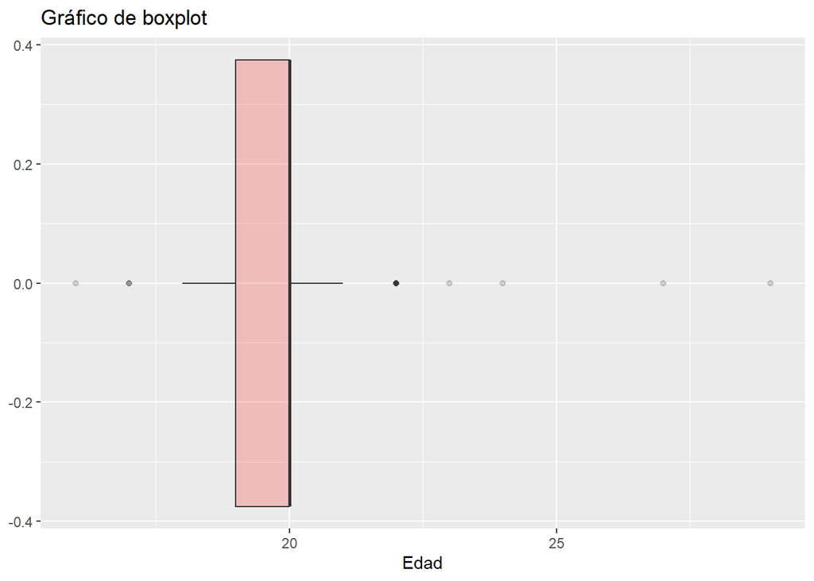

```r
color= c("red")
ggplot(DFN, aes(x=Edad))  + geom_boxplot(alpha= .2,fill = color) +xlab('Edad') +ggtitle('Gráfico de boxplot') #Datos atipicos  summary(DFN$Edad)
```

**Peso**

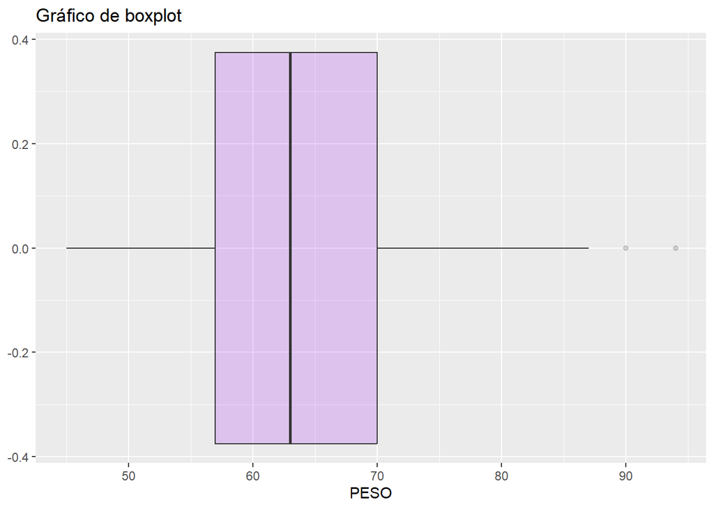

```r
#PESO
color= "purple"
ggplot(DFN, aes(x=Peso))+geom_boxplot(alpha= .2,fill = color) + xlab('PESO')  +ggtitle('Gráfico de boxplot') #tabla general
```

```r
summary(DFN$Peso) #vista general de los datos atipicos
```

```
##    Min. 1st Qu.  Median    Mean 3rd Qu.    Max.
##    45.0    57.0    63.0    63.9    70.0    94.0
```

```r
boxplot.stats(DFN$Peso)
```

```
## $stats
## [1] 45 57 63 70 87
##
## $n
## [1] 191
##
## $conf
## [1] 61.51378 64.48622
##
## $out
## [1] 90 94
```

**Sexo**

- Variable categórica nominal.
- La cantidad del sexo masculino es de 116 estudiantes y del sexo femenino es de 74 estudiantes.
- La cantidad de estudiantes de otro sexo es solo uno.
- Existe una mayoría en el sexo masculino que supera al sexo femenino de los estudiantes encuestados.

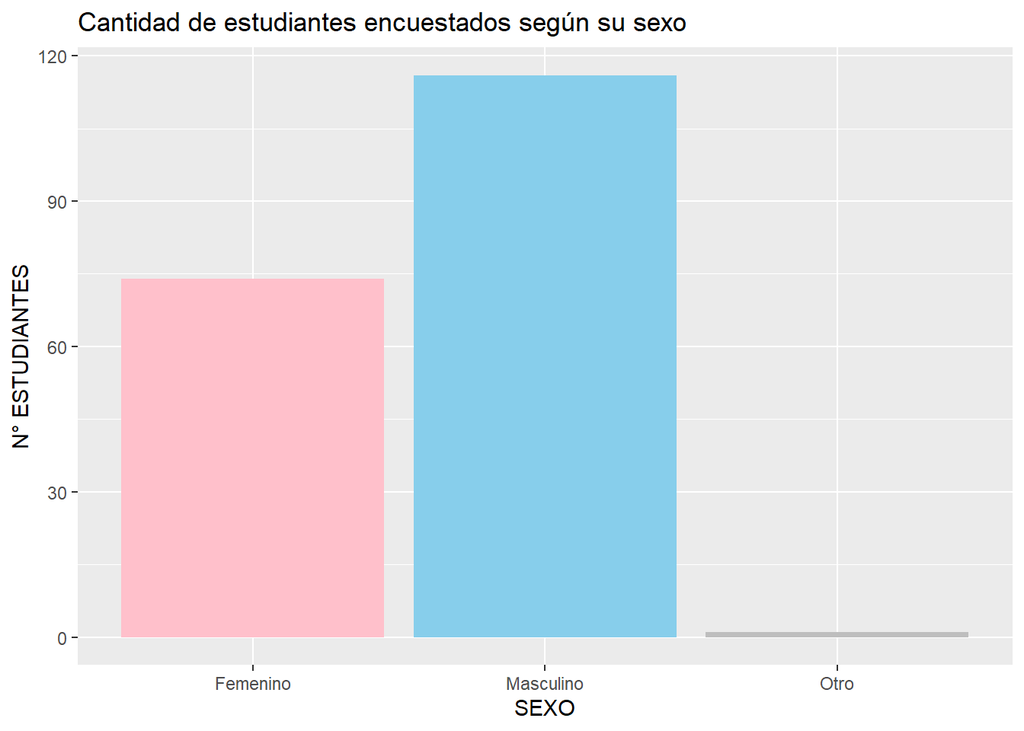

```r
#SEXO
colors=c("pink","skyblue","gray")
ggplot(DFN, aes(x=Sexo))  +geom_bar(fill = colors) +xlab('SEXO') +ylab('N° ESTUDIANTES') +ggtitle('Cantidad de estudiantes encuestados según su sexo')
```

```r
table(DFN$Sexo)
```

```
##
##  Femenino Masculino      Otro
##        74       116         1
```

**Precio máximo de un almuerzo**

- Variable numérica continua
- El valor mínimo es 10
- El valor máximo es 40
- El valor que más se repite es 15
- Gracias a la gráfica del boxplot podemos notar que tenemos 3 datos atípicos que corresponden a precios mayores a 20 soles.
- Su rango intercuartil es 6, se puede decir que la mitad de los valores se encuentran juntos.

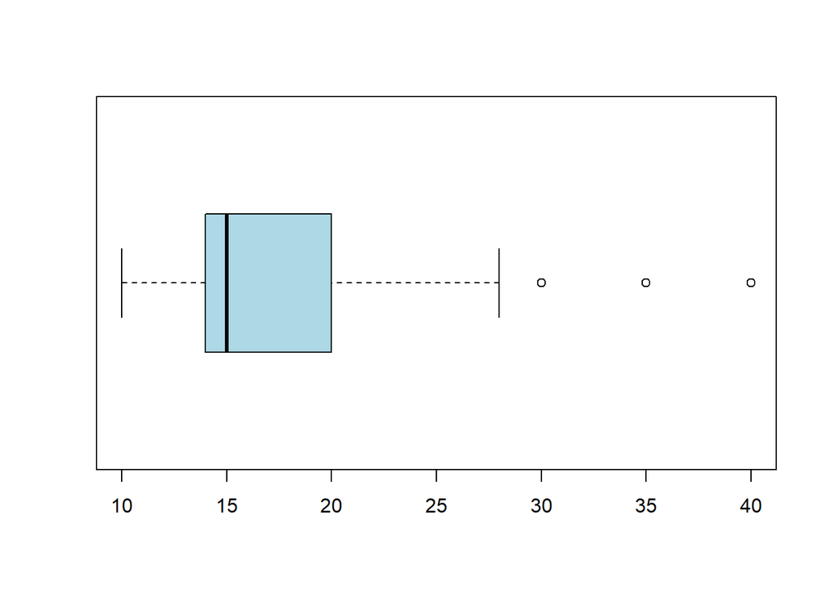

```r
boxplot(DFN$PrecioMaximo,col="lightblue",horizontal = T)
```

**Tiempo en encontrar comida en UTEC**

- Variable numérica discreta
- El tiempo mínimo en encontrar comida en UTEC es 5 min
- EL tiempo máximo en encontrar comida en UTEC es 45 min
- Esta variable es bimodal y los tiempos que más se repiten son 5 y 10 min
- Gracias al boxplot podemos notar que hay 2 valores atípicos que corresponden a valores mayores de 20 min
- Su rango intercuartil es de 13, se puede decir que la mitad de los datos se encuentran relativamente juntos.

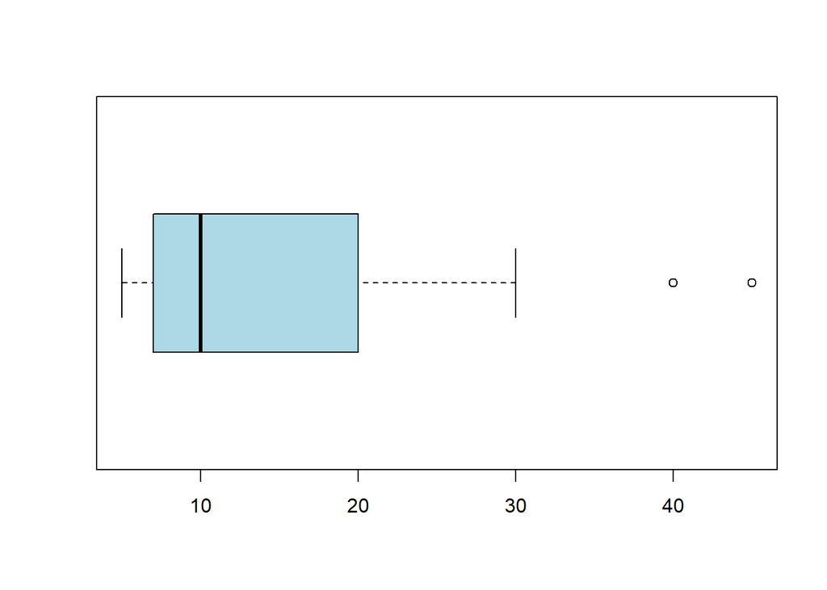

```r
boxplot(DFN$TiempoUtec,col="lightblue",horizontal = T)
```

**Precio mínimo dispuesto a pagar por un almuerzo vegetariano**

- Variable númerica continua.
- El menor valor es 10 soles.
- El máximo valor es de 20 soles.
- El valor que más se repite es 10 soles.
- Gracias al gráfico de boxplot podemos notar que no hay datos atípicos.
- Su rango intercuartil es 5. Sin embargo, teniendo en cuenta nuestros datos, significa que la mitad de nuestros datos se encuentran dispersos.

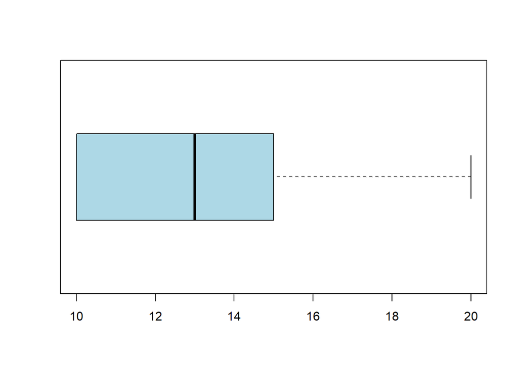

```r
boxplot(DFN$VegMin,col="lightblue",horizontal = T)
```

**Nivel de satisfacción de un almuerzo en UTEC**

- Variable categórica ordinal
- La variable que más se repite es “No compro alimentos en UTEC”
- La variables que menos se repite es “Completamente satisfecho”

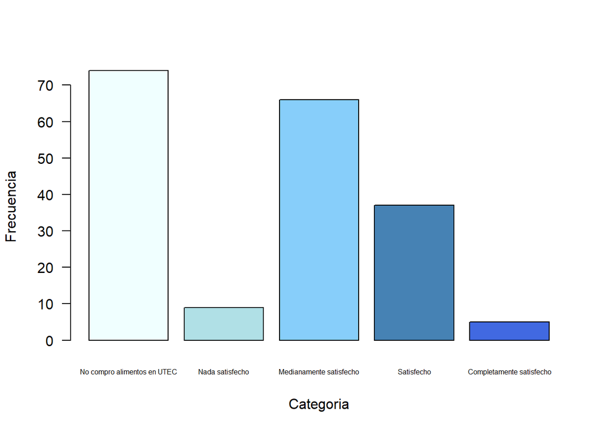

```r
categorias <- c("No compro alimentos en UTEC","Nada satisfecho", "Medianamente satisfecho",   "Satisfecho","Completamente satisfecho")
frecuencias <- c(74,9, 66,   37,5)
colores <- c("azure", "powderblue", "lightskyblue", "steelblue", "royalblue")
barplot(frecuencias,
        names.arg = categorias,
        ylab = "Frecuencia",
        xlab = "Categoria",
        col = colores,  # Asignar colores definidos
        las = 1,        # Rotar etiquetas del eje x
        cex.names = 0.5 # Ajustar el tamaño de las letras
)
```

**Motivo para adoptar el vegetarianismo**

- Variable categórica nominal
- La variable que más se repite es “No adoptaría el veganismo o el vegetarianismo”
- La variable que menos se repite es “Creencias”

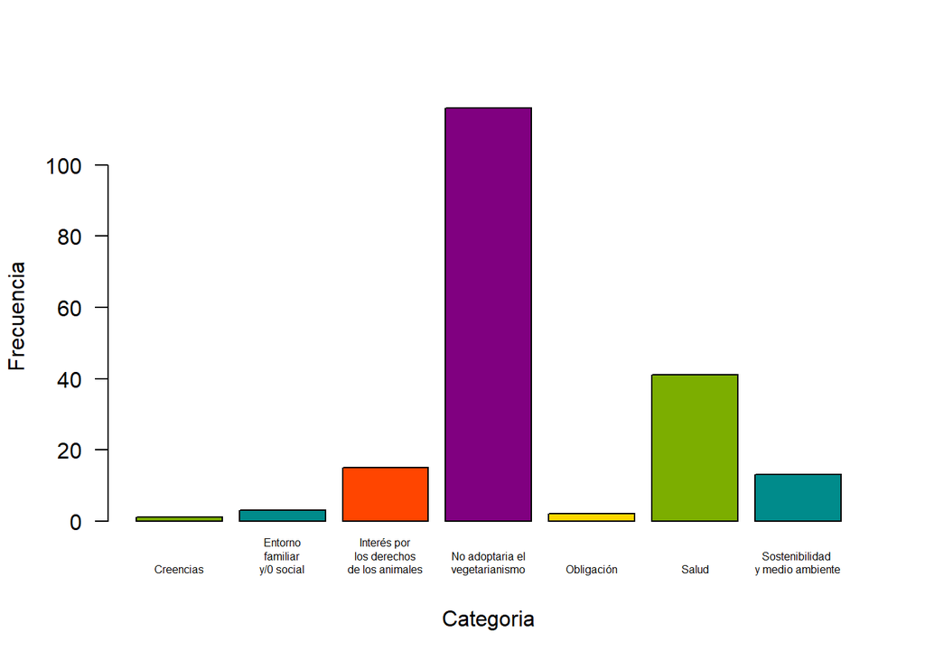

```r
categorias <- c(
"Creencias",
"Entorno
familiar
y/0 social",
"Interés por
los derechos
de los animales",
"No adoptaria el
vegetarianismo",
"Obligación",
"Salud",
"Sostenibilidad
y medio ambiente")
frecuencias <- c(1, 3, 15, 116, 2, 41, 13)
colores <- c("#7CAE00", "#008B8B", "#FF4500", "#800080", "#FFD700")
barplot(frecuencias,
        names.arg = categorias,
        ylab = "Frecuencia",
        xlab = "Categoria",
        col = colores,  # Asignar colores definidos
        las = 1,        # Rotar etiquetas del eje x
        cex.names = 0.5 # Ajustar el tamaño de las letras
)
```

**Conocimiento sobre el vegetarianismo**

- Variable categórica ordinal.
- La variable que más se repite es “Básico”.
- La variable que menos se repite es “Avanzado”.
- La mediana es “Básico”.

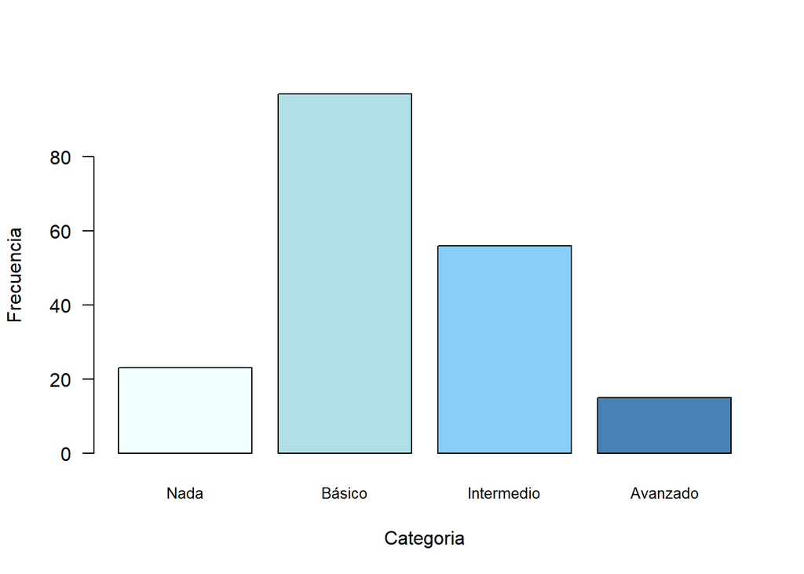

```r
categorias <- c("Nada", "Básico", "Intermedio", "Avanzado")
frecuencias <- c(23,97,56,15)

# Definir colores parecidos
colores <- c("azure", "powderblue", "lightskyblue", "steelblue" )

# Ajustar el tamaño de las letras y la orientación del eje x utilizando 'cex.names' y 'las' en barplot()
barplot(frecuencias,
        names.arg = categorias,
        ylab = "Frecuencia",
        xlab = "Categoria",
        col = colores,  # Asignar colores definidos
        las = 1,        # Rotar etiquetas del eje x
        cex.names = 0.8 # Ajustar el tamaño de las letras
)
```

**Carrera**

Variable categórica nominal.

- El mayor porcentaje de estudiantes es de la carrera de Ingeniería civil con 42.41% del total de encuestados.
- El menor porcentaje de estudiantes es de la carrera de Ingeniera de la Energía y Mecatrónica.

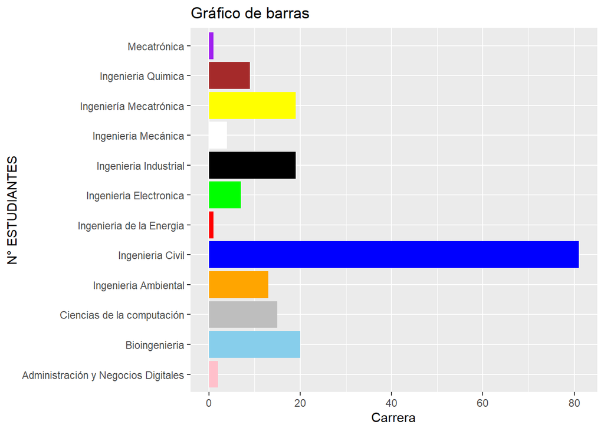

```r
colorss=c("pink","skyblue","gray","orange","blue","red","green","black","white","yellow","brown","purple")
ggplot(DFN, aes(y=Carrera))  +
 geom_bar(fill=colorss) +xlab('Carrera') +ylab('N° ESTUDIANTES') +ggtitle('Gráfico de barras')
```

```r
#porcetanje de los estudiantes por carrera
round(table(DFN$Carrera)/nrow(DFN)*100,3)
```

```
##
## Administración y Negocios Digitales                       Bioingenieria
##                               1.047                              10.471
##          Ciencias de la computación                Ingenieria Ambiental
##                               7.853                               6.806
##                    Ingenieria Civil            Ingenieria de la Energia
##                              42.408                               0.524
##              Ingenieria Electronica               Ingenieria Industrial
##                               3.665                               9.948
##                 Ingenieria Mecánica              Ingeniería Mecatrónica
##                               2.094                               9.948
##                  Ingenieria Quimica                         Mecatrónica
##                               4.712                               0.524
```

### Descriptores de bivariables y gráficos

- **Sexo - Inclinación por el vegetarianismo**

**Hipótesis:** Las mujeres tienden a inclinarse más por el vegetarianismo que los hombres y habría una mayoría de estudiantes que no son vegetarianos o veganos en comparación a los que sí lo son.

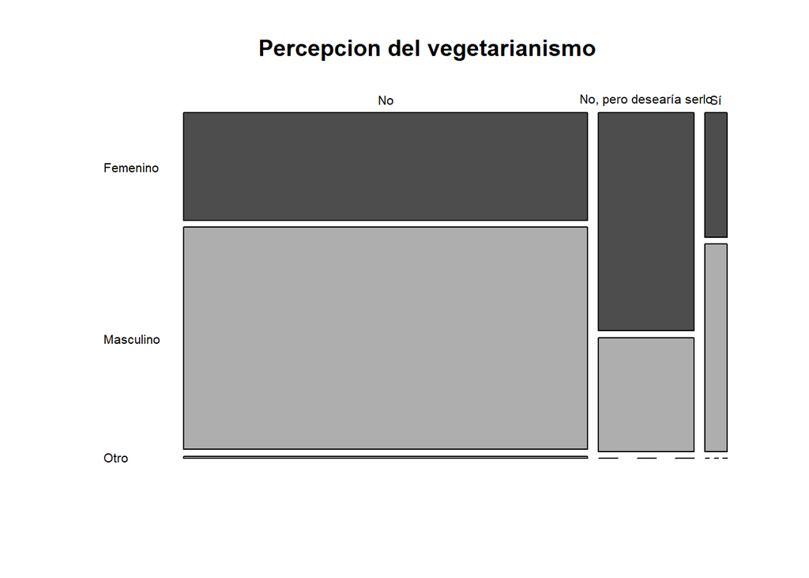

```r
tab<-table(DFN$Vegetarianismo,DFN$Sexo)
mosaicplot(tab, main="Percepcion del vegetarianismo",# introducimos las variables que queremos cruzar
           color = T, # vector de colores, si se pone color = T, queda en banco y negro.
           las = 1) # estilo de los ejes
```

- **Tiempo en encontrar almuerzos en UTEC - Nivel de satisfacción de almuerzos en UTEC**

**Hipótesis:** Los estudiantes de 4to ciclo de UTEC del periodo 2023-1 que demoran más tiempo en adquirir un almuerzo en UTEC tienen un nivel de satisfacción bajo con la compra de sus almuerzos y aquellos que demoran menos en la compra, presentan un nivel de satisfacción alto.

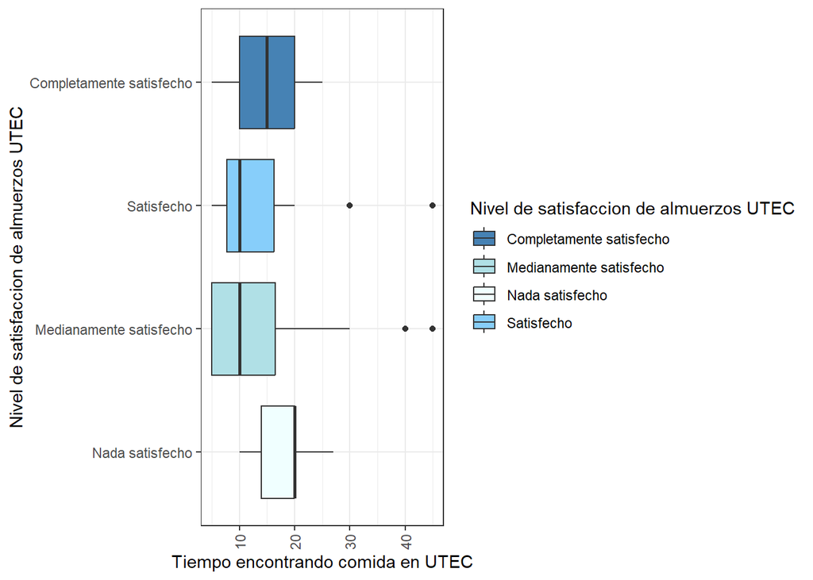

```r
orden_categorias <- c("Nada satisfecho", "Medianamente satisfecho", "Satisfecho", "Completamente satisfecho")

ggplot(DFN[DFN$Satisfaccion != "No compro alimentos en UTEC", ], aes(x = reorder(Satisfaccion, match(Satisfaccion, orden_categorias)), y = TiempoUtec, fill = factor(Satisfaccion))) +
  geom_boxplot() +
  scale_fill_manual(values = c("steelblue", "powderblue", "azure","lightskyblue" )) +
  labs(x = "Nivel de satisfaccion de almuerzos UTEC", y = "Tiempo encontrando comida en UTEC", fill = "Nivel de satisfaccion de almuerzos UTEC") +
  theme_bw() +
  theme(axis.text.x = element_text(angle = 90, vjust = 0.5, hjust = 1)) +
  coord_flip()
```

- **Predisposición en optar por una dieta vegetariana con la cantidad mínima dispuesta a pagar por un almuerzo vegetariano**

**Hipótesis:** Las personas que son menos afines a involucrarse con una dieta vegetariana están menos dispuestos a pagar por un almuerzo vegetariano..

**Del gráfico inferimos:**

Al ver el tamaño de la cajas podemos evidenciar el poco conocimiento sobre el estándar del precio de un almuerzo vegetariano. Mientra que en las cajas de menor tamaño, lo que significa menos dispersión podemos inferir que existe más conocimiento o se tiene una idea del costo de un almuerzo vegetariano estándar.

**Conclusión:** Se confirma la hipótesis planteada.

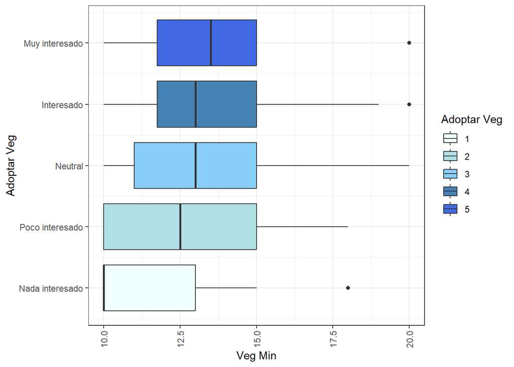

```r
        nombres_valores <- c("Nada interesado", "Poco interesado", "Neutral", "Interesado", "Muy interesado")

ggplot(DFN, aes(x = AdoptarVeg, y = VegMin, fill = factor(AdoptarVeg))) +
  geom_boxplot() +
  scale_fill_manual(values = c("azure", "powderblue", "lightskyblue", "steelblue", "royalblue")) +
  labs(x = "Adoptar Veg", y = "Veg Min", fill = "Adoptar Veg") +
  scale_x_continuous(labels = nombres_valores, breaks = 1:5) +
  theme_bw() +
  theme(axis.text.x = element_text(angle = 90, vjust = 0.5, hjust = 1)) +
  coord_flip()
```

- **La preocupación por la crueldad animal en la producción de alimentos respecto al sexo de los estudiantes de Utec**

**Del gráfico se infiere** que existe las estudiantes delsexo femenino de la universidad Utec del 4to y 5to ciclo del año 2023 se encuentran más preocupadas por la crueldad animal que los estudiantes del sexo masculino. Además podemos observar que hay una mayor concentración de estudiantes que se encuentran regularmente preocupados por la crueldad animal a diferencia de los otros niveles de preocupación.

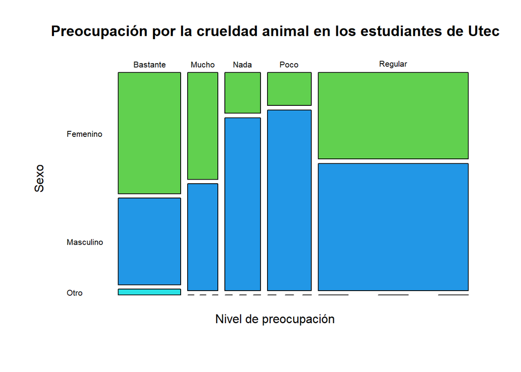

```r
tab<-table(DFN$CrueldadAnimal,DFN$Sexo)
    mosaicplot(tab, main="Preocupación por la crueldad animal en los estudiantes de Utec",xlab="Nivel de preocupación", ylab = "Sexo",# introducimos las variables que queremos cruzar
               color = 3:5, # vector de colores, si se pone color = T, queda en banco y negro.
               las = 1) # estilo de los ejes
```

- **Nivel de conocimiento sobre el vegetarianismo con el sexo de los estudiantes de Utec**

**Del gráfico se infiere:** Los estudiantes del sexo femenino poseen un mayor conocimiento acerca del vegetarianismo en comparación a los varones. Sin embargo, la mayor concentración de estudiantes del sexo femenino conocen lo básico sobre el concepto de vegetarianismo al igual que los estudiantes del sexo masculino. Además se puede observar que los estudiantes de otro sexo tienen un mayor conocimiento intermedio sobre el conocimiento del vegetarianismo. Por ultimo, en el gráfico se analiza una mayor cantidad de estudiantes del sexo masculino que tienen casi nada de conocimiento acerca del vegetarianismo, esto a diferencia de las mujeres.

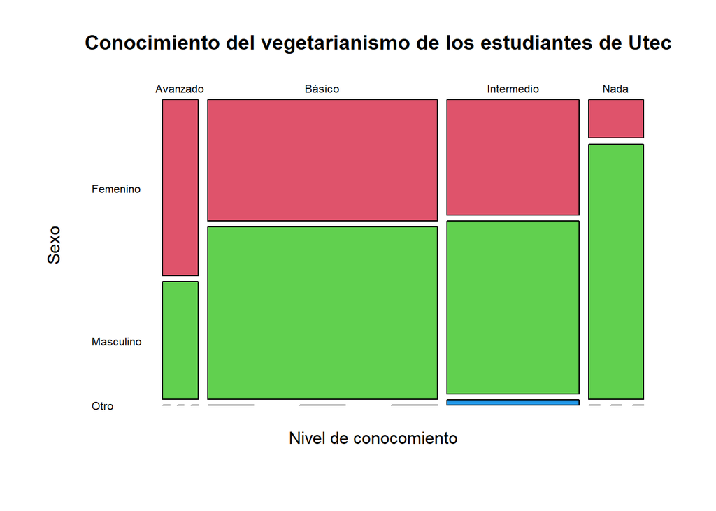

```r
 tab<-table(DFN$Conocimiento,DFN$Sexo)
    mosaicplot(tab, main="Conocimiento del vegetarianismo de los estudiantes de Utec",# introducimos las variables que queremos cruzar
               color = 2:4,xlab = "Nivel de conocomiento  ",ylab = "Sexo", # vector de colores, si se pone color = T, queda en banco y negro.
               las = 1) # estilo de los ejes
```

- **Motivo para adoptar o por el que se adopta el vegetarianismo en relación al sexo de los estudiantes**

**Conclusión:** Se confirma el motivo por el cual los alumnos optan por el veganismo.

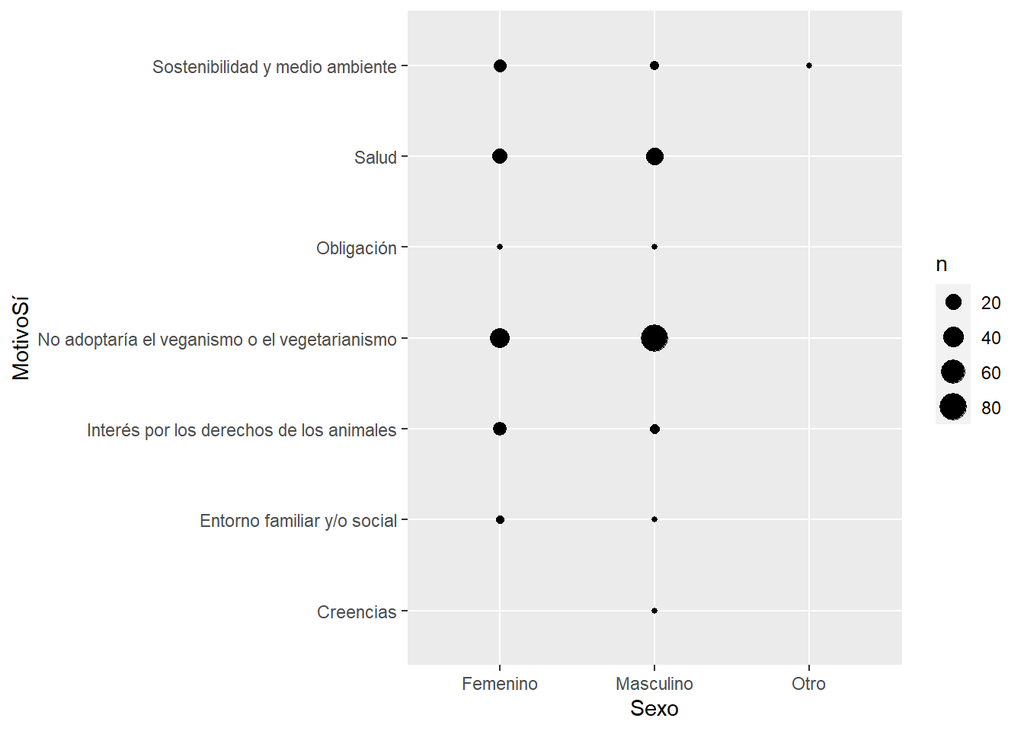

```r
#MotivoSí y Sexo
ggplot(data = DFN) +
  geom_count(aes(Sexo, MotivoSí))
```

**Motivo por el cual no adoptan el vegetarianismo en relación al sexo de los estudiantes**

- **Del gráfico inferimos:** Los estudiantes de 4to ciclo de UTEC del periodo 2023-1 no optarían por una dieta vegana debido al gusto personal y al costo de implementarla en el día a día.
- **Conclusión:** No optarían en su mayoría por el gusto y el costo.

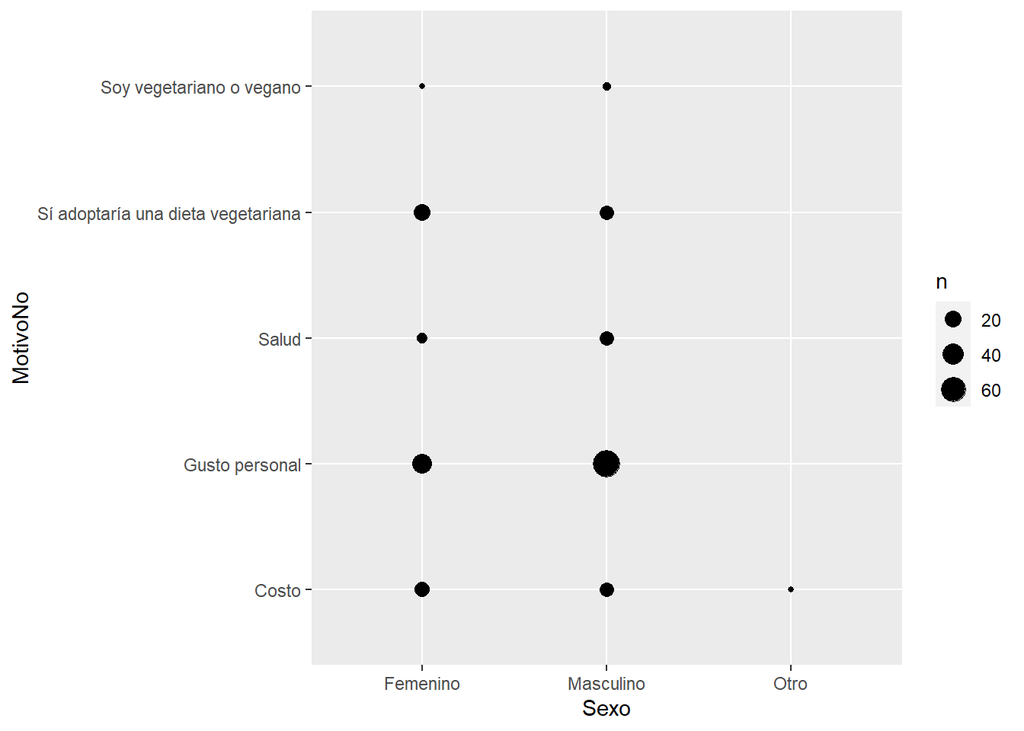

```r
#MotivoNo y Sexo
ggplot(data = DFN) +
 geom_count(aes(Sexo,MotivoNo))
```